# New data Analytics for tvg_cd_data

This notebook is going to analyse the `tfg_cd_data.csv` file and observe how it can be used for machine learning application

```python
# Importing the required modules
import pandas as pd
import numpy as np
import matplotlib.pyplot as plt
import os
import warnings
warnings.filterwarnings('ignore')
%matplotlib inline
```

```python
df = pd.read_csv(os.path.join('tvg_cd_data.csv'))
df.tail()
```

|  | racedater | tvgtrackcode | race | bettinginterestnumber | horsename | morninglineodds | currentodds | tvghorseweight | tvghorsedamsirename | tvghorseage | ... | tvghorsenumberofwins | tvghorsenumberofstarts | tvghorsepowerrating | tvghorseaveragespeed | tvghorseaverageclassrating | currentodds.1 | winpayout | placepayout | showpayout | scratched |
| --- | --- | --- | --- | --- | --- | --- | --- | --- | --- | --- | --- | --- | --- | --- | --- | --- | --- | --- | --- | --- | --- |
| 2224 | 2020-05-29 | cd | 9 | 7 | out cold | 20.0 | SC | 123 | northern afleet | 4 | ... | 1 | 2 | 69.8 | 75 | 81 | SC | 0.0 | 0.0 | 0.0 | 1 |
| 2225 | 2020-05-29 | cd | 9 | 8 | irish spirit | 3.0 | 3 | 123 | forest camp | 5 | ... | 0 | 1 | 78.4 | 89 | 97 | 3 | 0.0 | 0.0 | 0.0 | 0 |
| 2226 | 2020-05-29 | cd | 9 | 9 | alex's strike | 8.0 | 4 | 123 | smart strike | 4 | ... | 1 | 8 | 84.4 | 80 | 87 | 4 | 0.0 | 0.0 | 0.0 | 0 |
| 2227 | 2020-05-29 | cd | 9 | 10 | heros reward | 10.0 | 2 | 118 | smart strike | 3 | ... | 1 | 3 | 86.1 | 77 | 90 | 2 | 6.2 | 4.2 | 3.8 | 0 |
| 2228 | 2020-05-29 | cd | 9 | 11 | nice of me | 20.0 | 19 | 123 | allen's prospect | 4 | ... | 1 | 7 | 79.2 | 74 | 90 | 19 | 0.0 | 0.0 | 8.4 | 0 |

5 rows × 22 columns

Going to draw some histograms for this dataset

```python
column_list = [i for i in df.columns]
print(column_list)
```

[output not shown]

```python
print(df.tvghorseweight.min())
print(max(df.tvghorseweight))
```

```
0
126
```

# Histogram Analysis

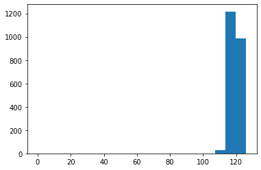

```python
fig, ax = plt.subplots()
n_bins = 20
ax.hist(x=df.tvghorseweight, bins=n_bins);
```

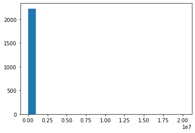

```python
fig, ax = plt.subplots()
n_bins = 20
ax.hist(x=df.tvghorseage, bins=n_bins);
```

There appears to be a huge amount of range, After inspecting the data on jupyter labs, there are horse called `(null)` so we shall get rid of them and find the true values

```python
df_copy = df.copy()
```

```python
df_copy = df_copy[df.tvghorsedamsirename != '(null)']
df_copy.tail()
```

|  | racedater | tvgtrackcode | race | bettinginterestnumber | horsename | morninglineodds | currentodds | tvghorseweight | tvghorsedamsirename | tvghorseage | ... | tvghorsenumberofwins | tvghorsenumberofstarts | tvghorsepowerrating | tvghorseaveragespeed | tvghorseaverageclassrating | currentodds.1 | winpayout | placepayout | showpayout | scratched |
| --- | --- | --- | --- | --- | --- | --- | --- | --- | --- | --- | --- | --- | --- | --- | --- | --- | --- | --- | --- | --- | --- |
| 2224 | 2020-05-29 | cd | 9 | 7 | out cold | 20.0 | SC | 123 | northern afleet | 4 | ... | 1 | 2 | 69.8 | 75 | 81 | SC | 0.0 | 0.0 | 0.0 | 1 |
| 2225 | 2020-05-29 | cd | 9 | 8 | irish spirit | 3.0 | 3 | 123 | forest camp | 5 | ... | 0 | 1 | 78.4 | 89 | 97 | 3 | 0.0 | 0.0 | 0.0 | 0 |
| 2226 | 2020-05-29 | cd | 9 | 9 | alex's strike | 8.0 | 4 | 123 | smart strike | 4 | ... | 1 | 8 | 84.4 | 80 | 87 | 4 | 0.0 | 0.0 | 0.0 | 0 |
| 2227 | 2020-05-29 | cd | 9 | 10 | heros reward | 10.0 | 2 | 118 | smart strike | 3 | ... | 1 | 3 | 86.1 | 77 | 90 | 2 | 6.2 | 4.2 | 3.8 | 0 |
| 2228 | 2020-05-29 | cd | 9 | 11 | nice of me | 20.0 | 19 | 123 | allen's prospect | 4 | ... | 1 | 7 | 79.2 | 74 | 90 | 19 | 0.0 | 0.0 | 8.4 | 0 |

5 rows × 22 columns

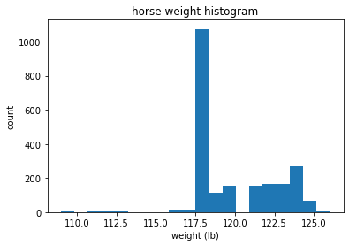

```python
fig, ax = plt.subplots()
n_bins = 20
ax.hist(x=df_copy.tvghorseweight, bins=n_bins);
ax.set(title='horse weight histogram', xlabel='weight (lb)', ylabel='count');
```

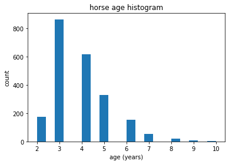

```python
fig, ax = plt.subplots()
n_bins = 20
ax.hist(x=df_copy.tvghorseage, bins=n_bins);
ax.set(title='horse age histogram', xlabel='age (years)', ylabel='count');
```

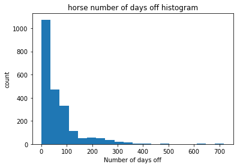

```python
fig, ax = plt.subplots()
n_bins = 20
ax.hist(x=df_copy.tvghorsedaysoff, bins=n_bins);
ax.set(title='horse number of days off histogram', xlabel='Number of days off', ylabel='count');
```

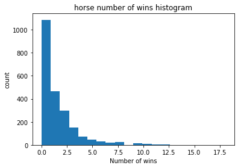

```python
fig, ax = plt.subplots()
n_bins = 20
ax.hist(x=df_copy.tvghorsenumberofwins, bins=n_bins);
ax.set(title='horse number of wins histogram', xlabel='Number of wins', ylabel='count');
```

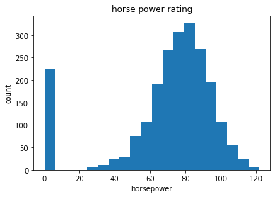

```python
fig, ax = plt.subplots()
n_bins = 20
ax.hist(x=df_copy.tvghorsepowerrating, bins=n_bins);
ax.set(title='horse power rating', xlabel='horsepower', ylabel='count');
```

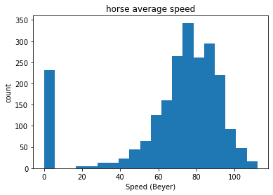

```python
fig, ax = plt.subplots()
n_bins = 20
ax.hist(x=df_copy.tvghorseaveragespeed, bins=n_bins);
ax.set(title='horse average speed', xlabel='Speed (Beyer)', ylabel='count');
```

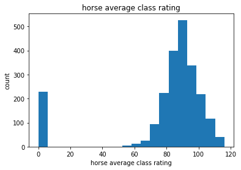

```python
fig, ax = plt.subplots()
n_bins = 20
ax.hist(x=df_copy.tvghorseaverageclassrating, bins=n_bins);
ax.set(title='horse average class rating', xlabel='horse average class rating', ylabel='count');
```

There appears to be a consistant theme here, there is a value of zeros at the same count, lets get rid of them

```python
df_copy = df_copy[df.tvghorseaverageclassrating != 0]
df_copy.tail()
```

|  | racedater | tvgtrackcode | race | bettinginterestnumber | horsename | morninglineodds | currentodds | tvghorseweight | tvghorsedamsirename | tvghorseage | ... | tvghorsenumberofwins | tvghorsenumberofstarts | tvghorsepowerrating | tvghorseaveragespeed | tvghorseaverageclassrating | currentodds.1 | winpayout | placepayout | showpayout | scratched |
| --- | --- | --- | --- | --- | --- | --- | --- | --- | --- | --- | --- | --- | --- | --- | --- | --- | --- | --- | --- | --- | --- |
| 2224 | 2020-05-29 | cd | 9 | 7 | out cold | 20.0 | SC | 123 | northern afleet | 4 | ... | 1 | 2 | 69.8 | 75 | 81 | SC | 0.0 | 0.0 | 0.0 | 1 |
| 2225 | 2020-05-29 | cd | 9 | 8 | irish spirit | 3.0 | 3 | 123 | forest camp | 5 | ... | 0 | 1 | 78.4 | 89 | 97 | 3 | 0.0 | 0.0 | 0.0 | 0 |
| 2226 | 2020-05-29 | cd | 9 | 9 | alex's strike | 8.0 | 4 | 123 | smart strike | 4 | ... | 1 | 8 | 84.4 | 80 | 87 | 4 | 0.0 | 0.0 | 0.0 | 0 |
| 2227 | 2020-05-29 | cd | 9 | 10 | heros reward | 10.0 | 2 | 118 | smart strike | 3 | ... | 1 | 3 | 86.1 | 77 | 90 | 2 | 6.2 | 4.2 | 3.8 | 0 |
| 2228 | 2020-05-29 | cd | 9 | 11 | nice of me | 20.0 | 19 | 123 | allen's prospect | 4 | ... | 1 | 7 | 79.2 | 74 | 90 | 19 | 0.0 | 0.0 | 8.4 | 0 |

5 rows × 22 columns

Re-visualising

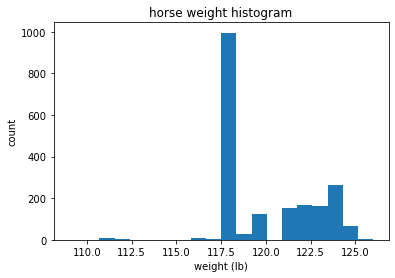

```python
fig, ax = plt.subplots()
n_bins = 20
ax.hist(x=df_copy.tvghorseweight, bins=n_bins);
ax.set(title='horse weight histogram', xlabel='weight (lb)', ylabel='count');
```

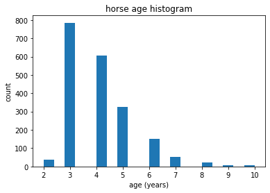

```python
fig, ax = plt.subplots()
n_bins = 20
ax.hist(x=df_copy.tvghorseage, bins=n_bins);
ax.set(title='horse age histogram', xlabel='age (years)', ylabel='count');
```

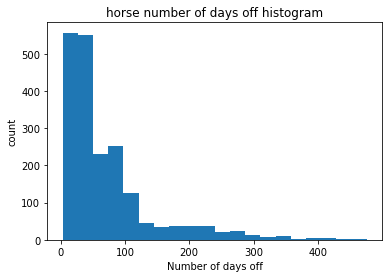

```python
fig, ax = plt.subplots()
n_bins = 20
ax.hist(x=df_copy.tvghorsedaysoff, bins=n_bins);
ax.set(title='horse number of days off histogram', xlabel='Number of days off', ylabel='count');
```

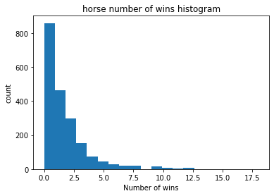

```python
fig, ax = plt.subplots()
n_bins = 20
ax.hist(x=df_copy.tvghorsenumberofwins, bins=n_bins);
ax.set(title='horse number of wins histogram', xlabel='Number of wins', ylabel='count');
```

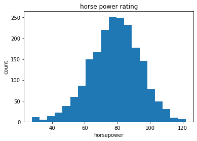

```python
fig, ax = plt.subplots()
n_bins = 20
ax.hist(x=df_copy.tvghorsepowerrating, bins=n_bins);
ax.set(title='horse power rating', xlabel='horsepower', ylabel='count');
```

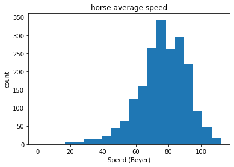

```python
fig, ax = plt.subplots()
n_bins = 20
ax.hist(x=df_copy.tvghorseaveragespeed, bins=n_bins);
ax.set(title='horse average speed', xlabel='Speed (Beyer)', ylabel='count');
```

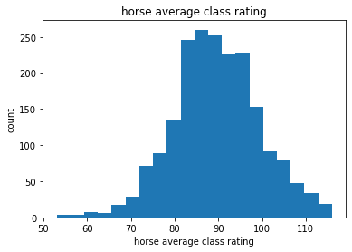

```python
fig, ax = plt.subplots()
n_bins = 20
ax.hist(x=df_copy.tvghorseaverageclassrating, bins=n_bins);
ax.set(title='horse average class rating', xlabel='horse average class rating', ylabel='count');
```

Data looks a lot cleaner and useable

I will analyse the data further and apply a regression model to measure the, predict and contrast the data.

```python
df_copy.to_csv('cleaned_tvg_cd_data.csv',index=False)
```

```python
x = len([i for i in df_copy.columns])
x
```

```
22
```

# Machine Learning

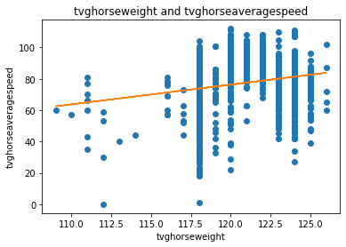

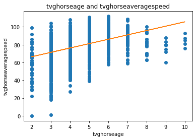

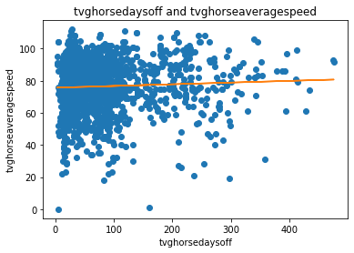

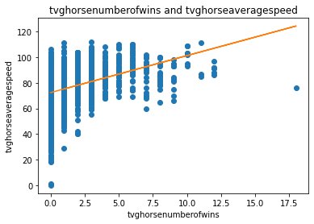

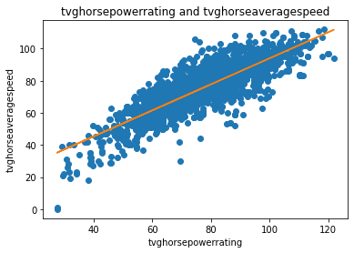

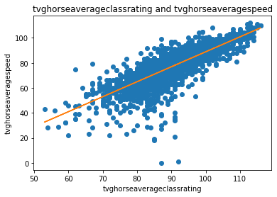

```python
features = [
    'tvghorseweight',
    'tvghorseage',
    'tvghorsedaysoff',
    'tvghorsenumberofwins',
    'tvghorsepowerrating',
    'tvghorseaverageclassrating'
]
target = 'tvghorseaveragespeed'

for i in features:
    x=df_copy[i]
    y=df_copy[target]
    m, c = np.polyfit(x, y, 1)
    plt.plot(x, y, 'o')
    plt.plot(x, m*x + c)
    plt.xlabel(i)
    plt.ylabel(target)
    plt.title(f'{i} and {target}')
    plt.show()
```

### This all looks good for the machine learning model

We decided that the features to be:

- Weight
- Age
- Days Off
- Number of Wins
- Power Rating
- Average Class Rating

We wanted to know the Buyer speed so we have that as the target.

```python
features = [
    'tvghorseweight',
    'tvghorseage',
    'tvghorsedaysoff',
    'tvghorsenumberofwins',
    'tvghorsepowerrating',
    'tvghorseaverageclassrating'
]

target = 'tvghorseaveragespeed'

X = df_copy[features]
y = df_copy[target].values.reshape(-1,1)
```

```python
from sklearn.model_selection import train_test_split
X_train, X_test, y_train, y_test = train_test_split(X, y, test_size=0.33, random_state=42)
```

```python
# scaling the data

from sklearn.preprocessing import StandardScaler
X_scaler = StandardScaler().fit(X_train)
y_scaler = StandardScaler().fit(y_train)
X_train_scaled = X_scaler.transform(X_train)
X_test_scaled = X_scaler.transform(X_test)
y_train_scaled = y_scaler.transform(y_train)
y_test_scaled = y_scaler.transform(y_test)
```

```python
from sklearn.linear_model import LinearRegression
model = LinearRegression()
model.fit(X_train_scaled, y_train_scaled)
```

```
LinearRegression()
```

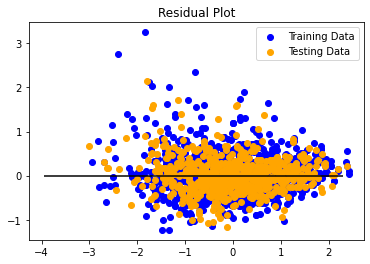

```python
predictions = model.predict(X_test_scaled)
model.fit(X_train_scaled, y_train_scaled)
plt.scatter(model.predict(X_train_scaled), model.predict(X_train_scaled) - y_train_scaled, c="blue", label="Training Data")
plt.scatter(model.predict(X_test_scaled), model.predict(X_test_scaled) - y_test_scaled, c="orange", label="Testing Data")
plt.legend()
plt.hlines(y=0, xmin=y_test_scaled.min(), xmax=y_test_scaled.max())
plt.title("Residual Plot")
plt.show()
```

Measuring the Linear Model

```python
from sklearn.metrics import mean_squared_error

MSE_linear_regression = mean_squared_error(y_test_scaled, predictions)
r2_linear_regression = model.score(X_test_scaled, y_test_scaled)
### END SOLUTION

print(f"MSE: {MSE_linear_regression}, R2: {r2_linear_regression}")
```

```
MSE: 0.16302412817702236, R2: 0.8393376790850877
```

Fitting, predicting and scoreing the Lasso Linear Model

```python
from sklearn.linear_model import Lasso

### BEGIN SOLUTION
lasso = Lasso(alpha=.01).fit(X_train_scaled, y_train_scaled)

predictions = lasso.predict(X_test_scaled)

MSE_lasso = mean_squared_error(y_test_scaled, predictions)
r2_lasso = lasso.score(X_test_scaled, y_test_scaled)
### END SOLUTION

print(f"MSE: {MSE_lasso}, R2: {r2_lasso}")
```

```
MSE: 0.164375594141657, R2: 0.8380057924438664
```

Fitting, predicting and scoreing the Ridge Linear Model

```python
from sklearn.linear_model import Ridge

### BEGIN SOLUTION
ridge = Ridge(alpha=.01).fit(X_train_scaled, y_train_scaled)

predictions = ridge.predict(X_test_scaled)

MSE_ridge = mean_squared_error(y_test_scaled, predictions)
r2_ridge = ridge.score(X_test_scaled, y_test_scaled)
### END SOLUTION

print(f"MSE: {MSE_ridge}, R2: {r2_ridge}")
```

```
MSE: 0.16302432612175946, R2: 0.8393374840080692
```

Fitting, predicting and scoreing the ElasticNet Model

```python
from sklearn.linear_model import ElasticNet

### BEGIN SOLUTION
elasticnet = ElasticNet(alpha=.01).fit(X_train_scaled, y_train_scaled)

predictions = elasticnet.predict(X_test_scaled)

MSE_elastic = mean_squared_error(y_test_scaled, predictions)
r2_elastic = elasticnet.score(X_test_scaled, y_test_scaled)
### END SOLUTION

print(f"MSE: {MSE_elastic}, R2: {r2_elastic}")
```

```
MSE: 0.16379617411249137, R2: 0.8385768181424015
```